# Section 1: The aim of this project

The aim of this project is to explore a time series using Meta’s Prophet forecasting system.

## What is Mauna Loa?

Mauna Loa, located on the Big Island of Hawaii, is the world’s largest active shield volcano by volume and area, comprising over half the island. Standing 13,681 feet (4,170 m) above sea level, it rises over 30,000 feet from the ocean floor. It is highly active, with its most recent eruption occurring in November 2022.

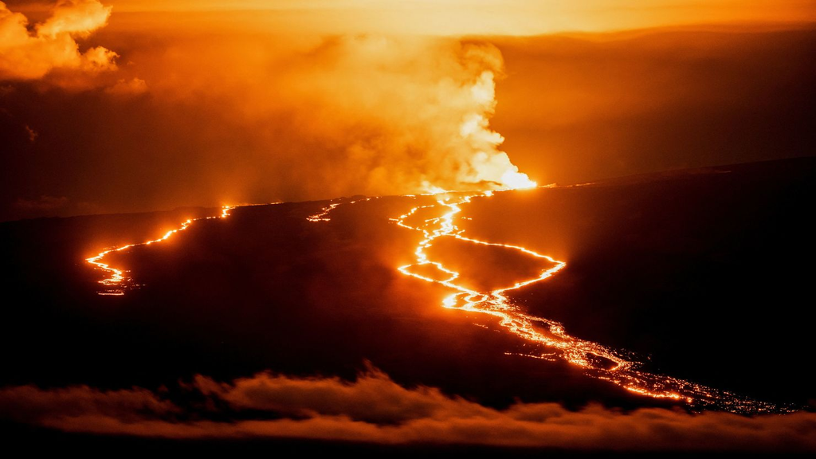

Now that we’ve caught up to speed with the beautiful but terrifying gem known as Mauna Loa. Lets get into the knitty gritty nerdy stuff and look at the numbers…

# Code

As mentioned before, the aim is to create a time series displaying how the atmospheric conditions in Mauna Loa have changed over time. We do this using the CO2 dataset.

The CO2 dataset contains monthly CO2 concentration values from 1959 to 1997, the data is expressed in parts per million.

We start by importing a forecasting system known as **Prophet**

Then we use the command **data** to load specified data sets, in this case the dataset is known as CO2.

We then use the command **time** to create a vector of times at which a time series was sampled. Conveniently, we can split up the messy data into neat monthly timeframes using **yearmon**.

```
##           Jan      Feb      Mar      Apr      May      Jun      Jul      Aug
## 1959 1959.000 1959.083 1959.167 1959.250 1959.333 1959.417 1959.500 1959.583
## 1960 1960.000 1960.083 1960.167 1960.250 1960.333 1960.417 1960.500 1960.583
## 1961 1961.000 1961.083 1961.167 1961.250 1961.333 1961.417 1961.500 1961.583
## 1962 1962.000 1962.083 1962.167 1962.250 1962.333 1962.417 1962.500 1962.583
## 1963 1963.000 1963.083 1963.167 1963.250 1963.333 1963.417 1963.500 1963.583
## 1964 1964.000 1964.083 1964.167 1964.250 1964.333 1964.417 1964.500 1964.583
## 1965 1965.000 1965.083 1965.167 1965.250 1965.333 1965.417 1965.500 1965.583
## 1966 1966.000 1966.083 1966.167 1966.250 1966.333 1966.417 1966.500 1966.583
## 1967 1967.000 1967.083 1967.167 1967.250 1967.333 1967.417 1967.500 1967.583
## 1968 1968.000 1968.083 1968.167 1968.250 1968.333 1968.417 1968.500 1968.583
## 1969 1969.000 1969.083 1969.167 1969.250 1969.333 1969.417 1969.500 1969.583
## 1970 1970.000 1970.083 1970.167 1970.250 1970.333 1970.417 1970.500 1970.583
## 1971 1971.000 1971.083 1971.167 1971.250 1971.333 1971.417 1971.500 1971.583
## 1972 1972.000 1972.083 1972.167 1972.250 1972.333 1972.417 1972.500 1972.583
```

[output cut: 65 more lines]

Now, we create a dataframe using the command **data.frame**. Then we use the forecaster prohpet to extrapolate some future data for 8 months ahead of the end date of the CO2 dataset.

For a quick sidenote, we assume there is not any daily or weekly seasonality here.

```
## Disabling weekly seasonality. Run prophet with weekly.seasonality=TRUE to override this.
```

```
## Disabling daily seasonality. Run prophet with daily.seasonality=TRUE to override this.
```

# **Time Series Analysis: CO₂ Concentration at Mauna Loa**

Finally, we plot our data as a time series to show the changes

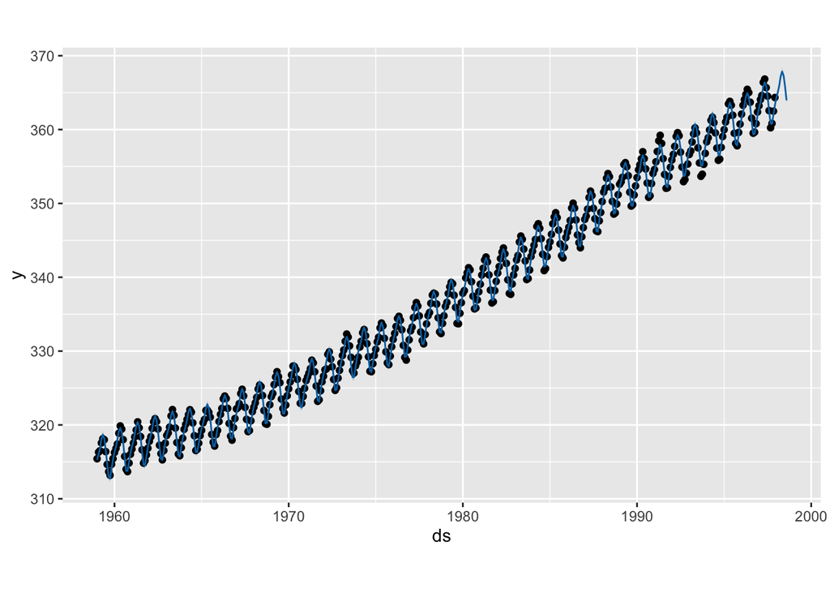

```r
plot(WeatherForecaster, Prediction)
```

## Long-term trend

The most prominent feature of the time series is a strong upward trend in atmospheric CO₂ concentrations over the observed period. At the beginning of the series in the late 1950s, CO₂ levels are approximately 315 ppm, while by the late 1990s they approach 365–370 ppm.

This steady increase indicates that atmospheric CO₂ has been accumulating over time. The increase appears approximately linear to slightly accelerating, suggesting that the rate of emissions into the atmosphere has been persistent and potentially increasing. To take a few guesses, this change in atmospheric CO2 levels is likely due to:

-Fossil fuel combustion -Volcanic activity -Deforestation and land-use change in the surrounding area

The overall increase of roughly 50 ppm over about four decades represents a substantial change in atmospheric composition and highlights the long-term impact of human and volcanic activity on the global carbon cycle.

## Seasonal Pattern

There is a clear and consistent seasonal cycle, visible as repeating peaks and troughs each year. These oscillations occur roughly once every 12 months, indicating strong annual seasonality.The seasonal fluctuations are caused mainly by biological processes.

Spring and Summer: During the growing season, plants absorb CO₂ through photosynthesis, causing atmospheric CO₂ concentrations to decline.

Autumn and Winter: As plants die back and photosynthesis decreases, respiration and decomposition release CO₂ back into the atmosphere, causing concentrations to rise.

This creates the characteristic saw-tooth pattern observed in the graph.

## Variability and noise

Aside from the dominant trend and seasonal cycle, the data shows minimal irregular fluctuations or random noise. The observations appear smooth and consistent, indicating:

-High measurement reliability -Stable monitoring procedures -Limited short-term disturbances affecting the data

Any noise is negligible relative to the magnitude of the trend and seasonal variation.

## An overview

The data has a persistent upward trajectory in CO₂ concentration over time. For the seasonality, it has a strong annual seasonal cycle with regular peaks and troughs.In terms of noise, there are mall random fluctuations around the trend-seasonal structure.

Because of the strong trend, the series is non-stationary, meaning its mean changes over time.